# Using Linear Regression to Explain Deputies Votes

Jose Manoel Ferreira

1 de outubro de 2018

```r
  # campos:
  # "sequencial_candidato" :(character) id do candidato
  # "nome": (character)
  # "uf": (character)
  # "partido": (character)
  # "quantidade_doacoes": (integer)
  # "quantidade_doadores": (integer) número de doadores diferentes
  # "total_receita": (double) soma em R$ das doações
  # "media_receita": (double) média das doações
  # "recursos_de_outros_candidatos/comites": (double) quantia em R$ das doações provenientes de outros candidatos ou comite partidário
  # "recursos_de_pessoas_fisicas": (double) quantia em R$ das doações provenientes de outros CPFs
  # "recursos_de_pessoas_juridicas": (double) quantia em R$ das doações provenientes de outros CNPJ
  # "recursos_proprios": (double) quantia em R$ das doações provenientes do próprio candidato
  # "recursos_de_partido_politico": (double) quantia em R$ das doações provenientes do partido político do candidato
  # "votos": (integer) variável alvo. Se refere ao número de votos na campanha de 2006 e 2010
  # "quantidade_despesas": (integer)
  # "quantidade_fornecedores": (integer) número de fornecedores/despesas diferentes
  # "total_despesa": (double) soma em R$ das despesas de campanha
  # "media_despesa": (double) média das despesas de campanha
  # "cargo": (character)
  # "Sexo":  (character)
  # "grau": (character) grau de instrução do candidato
  # "estado_civil": (character)
  # "ocupacao": (character) ocupação do candidato
```

Setting up a workspace

```r
setwd("~/git/data-analysis/lab02/")
```

Building our dataframes

```r
data2006 <- read.csv(("data/eleicoes_2006.csv"))
data2010 <- read.csv(("data/eleicoes_2010.csv"))
data2006_2010 <-read.csv(("data/eleicoes_2006_e_2010.csv"))
```

Removing the NA

```r
data2006 <- na.omit(data2006)
data2010 <- na.omit(data2010)
data2006_2010 <- na.omit(data2006_2010)
```

Library used

```r
library(reshape)
library(ggplot2)
library(dplyr)
library(lattice)
library(scales)
library(corrplot)
library("PerformanceAnalytics")
library(GGally)
```

Converting some categoric variables to factor, basically it set up a specific number to each value.

#### 2006

```r
data2006$sexo <- as.factor(data2006$sexo)
data2006$estado_civil <- as.factor(data2006$estado_civil)
data2006$uf <- as.factor(data2006$uf)
data2006$sexo <- as.factor(data2006$sexo)
data2006$grau <- as.factor(data2006$grau)
data2006$estado_civil <- as.factor(data2006$estado_civil)
data2006$ocupacao <- as.factor(data2006$ocupacao)
```

#### 2010

```r
data2010$sexo <- as.factor(data2010$sexo)
data2010$estado_civil <- as.factor(data2010$estado_civil)
data2010$uf <- as.factor(data2010$uf)
data2010$sexo <- as.factor(data2010$sexo)
data2010$grau <- as.factor(data2010$grau)
data2010$estado_civil <- as.factor(data2010$estado_civil)
data2010$ocupacao <- as.factor(data2010$ocupacao)
```

Bar charts to numeric variables

#### 2006

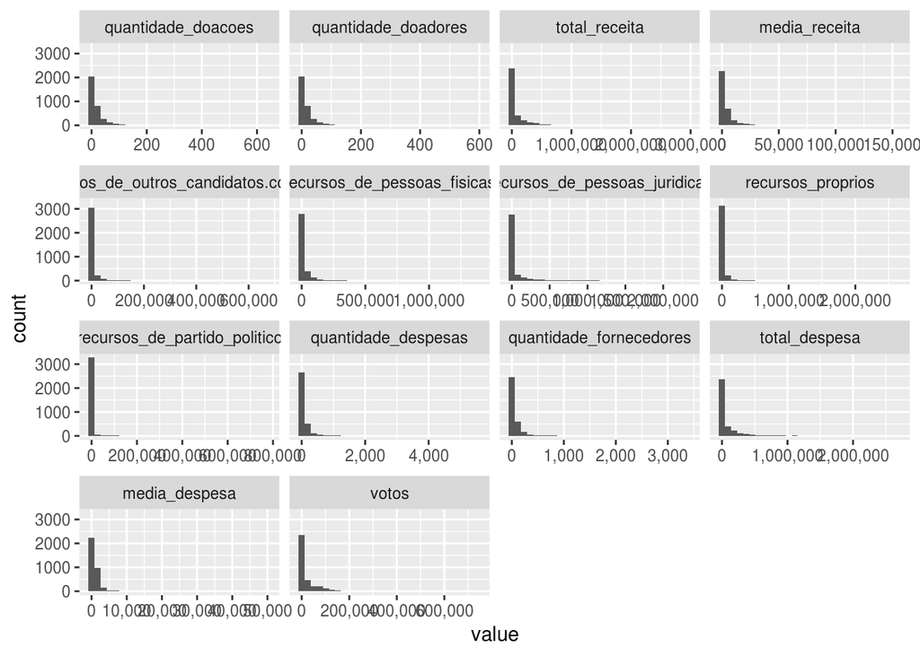

```r
d = melt(select(data2006, -sequencial_candidato, - ano))
ggplot(d,aes(x = value)) +
    facet_wrap(~variable, scales = "free_x") +
    scale_x_continuous(labels = comma) +
    geom_histogram()
```

#### 2010

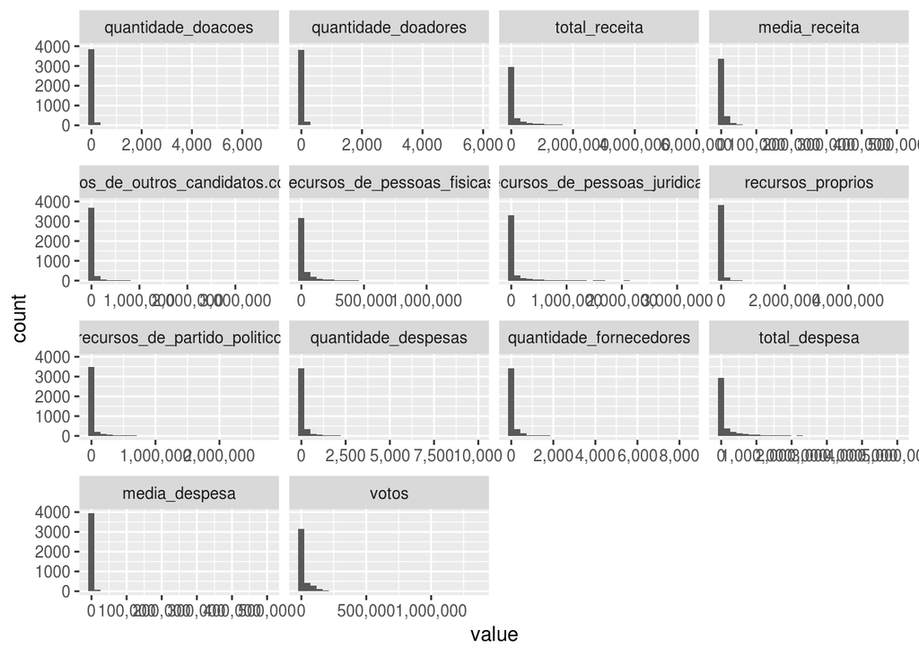

```r
d = melt(select(data2010, -sequencial_candidato, - ano))
ggplot(d,aes(x = value)) +
    facet_wrap(~variable, scales = "free_x") +
    scale_x_continuous(labels = comma) +
    geom_histogram()
```

It’s important to see the correlation between the variables, it will show to us the dependence between variables

#### 2006

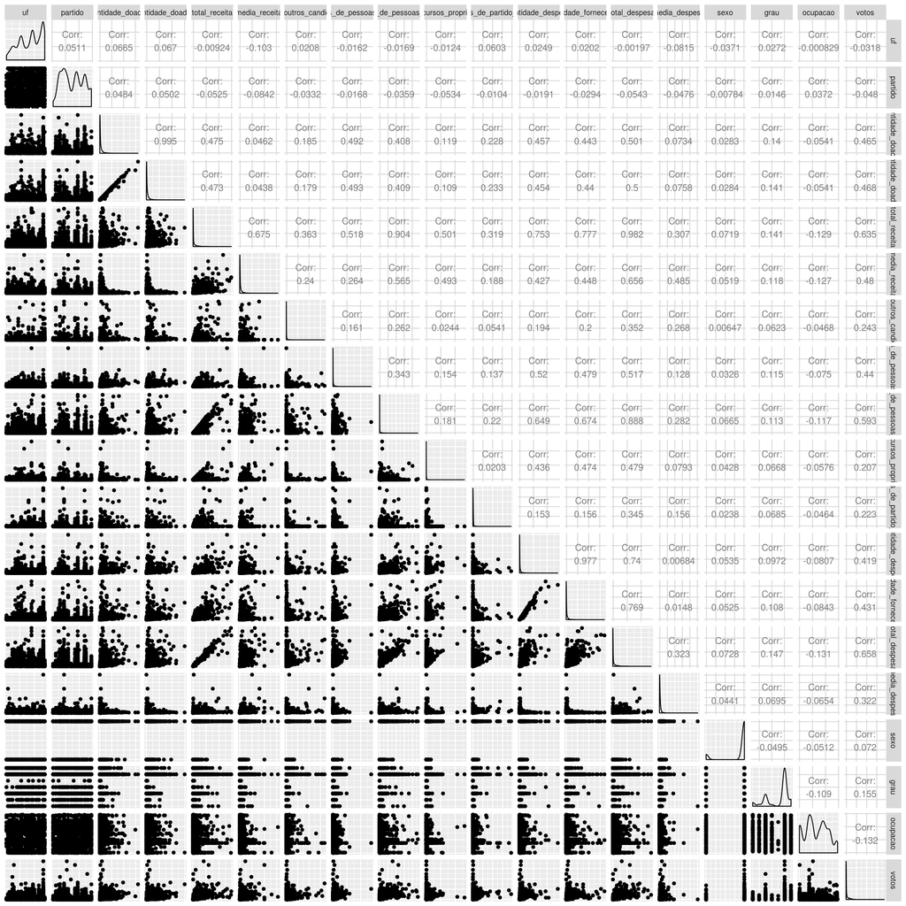

```r
data2006.correlation1 <- data2006 %>% select(-c(sequencial_candidato, nome, estado_civil, ano, cargo))

data2006.correlation <- data2006.correlation1  %>%
  mutate(uf = as.numeric(uf)) %>%
  mutate(partido = as.numeric(partido)) %>%
  mutate(sexo = as.numeric(sexo)) %>%
  mutate(grau = as.numeric(grau)) %>%
  mutate(ocupacao = as.numeric(ocupacao))


ggpairs(data2006.correlation, axisLabels = "none")
```

Seeing the correlation betweend the variables we can say that the variable whit the best correlation whit votos is total_despesa 0.658 flollowed by total_receita 0.635 whitch makes totally sense, because the total_receita is the values used to pay the expense and its represented by total_despesas. > * Greater correation is whit: > total_despesas corr: 0.658 > total_receita corr: 0.635 > * Smaller correlation is whit: > uf corr: - 0.0318 > partido: - 0.048

#### 2010

votos is our target variable, so let’s take a look and the correlation between votos and other variables. > * Greater correation is whit: > total_despesas corr: 0.637 > total_receita corr: 0.626 > * Smaller correlation is whit: > media_despesas corr: 0.0715 > uf corr: - 0.0425

#### 2006 and 2010

As we can see we’ve got a very similar result in both years, total_receita and total_despesa as the greater correlation and uf was the smalest.

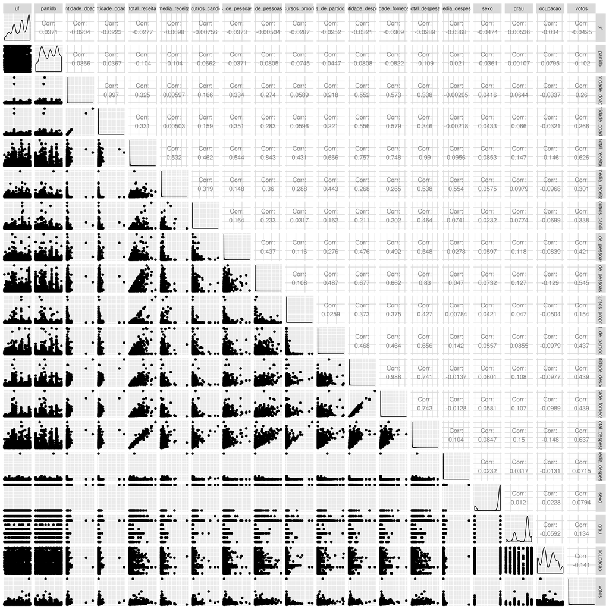

```r
data2010.correlation1 <- data2010 %>% select(-c(sequencial_candidato, nome, estado_civil, ano, cargo))

data2010.correlation <- data2010.correlation1  %>%
  mutate(uf = as.numeric(uf)) %>%
  mutate(partido = as.numeric(partido)) %>%
  mutate(sexo = as.numeric(sexo)) %>%
  mutate(grau = as.numeric(grau)) %>%
  mutate(ocupacao = as.numeric(ocupacao))


ggpairs(data2010.correlation, axisLabels = "none")
```

Multiple Regression Linear Model Whit all numeric variables

### 1. A multiple regresson model whit all variables is able to explain the y variation (total of votos) in 2006 and 2010?

#### 2006

```r
data2006.lm = lm(data2006$votos ~ data2006$uf + data2006$partido  + data2006$quantidade_doacoes + data2006$quantidade_doadores + data2006$total_receita + data2006$media_receita + data2006$recursos_de_outros_candidatos.comites + data2006$recursos_de_pessoas_fisicas + data2006$recursos_de_pessoas_juridicas + data2006$recursos_proprios + data2006$recursos_de_partido_politico + data2006$quantidade_despesas + data2006$quantidade_fornecedores + data2006$total_despesa + data2006$media_despesa + data2006$sexo + data2006$grau + data2006$estado_civil + data2006$ocupacao)

summary(data2006.lm)
```

```
##
## Call:
## lm(formula = data2006$votos ~ data2006$uf + data2006$partido +
##     data2006$quantidade_doacoes + data2006$quantidade_doadores +
##     data2006$total_receita + data2006$media_receita + data2006$recursos_de_outros_candidatos.comites +
##     data2006$recursos_de_pessoas_fisicas + data2006$recursos_de_pessoas_juridicas +
##     data2006$recursos_proprios + data2006$recursos_de_partido_politico +
##     data2006$quantidade_despesas + data2006$quantidade_fornecedores +
##     data2006$total_despesa + data2006$media_despesa + data2006$sexo +
##     data2006$grau + data2006$estado_civil + data2006$ocupacao)
##
## Residuals:
##     Min      1Q  Median      3Q     Max
## -210176   -8531   -1929    3749  633232
##
## Coefficients: (1 not defined because of singularities)
##                                                                                           Estimate
## (Intercept)                                                                             -1.865e+04
## data2006$ufAL                                                                            1.433e+04
## data2006$ufAM                                                                            1.675e+04
## data2006$ufAP                                                                            3.688e+03
## data2006$ufBA                                                                            2.704e+04
## data2006$ufCE                                                                            2.929e+04
## data2006$ufDF                                                                            9.075e+03
## data2006$ufES                                                                            1.431e+04
## data2006$ufGO                                                                            1.284e+04
## data2006$ufMA                                                                            2.418e+04
## data2006$ufMG                                                                            1.733e+04
## data2006$ufMS                                                                            1.230e+04
## data2006$ufMT                                                                            9.713e+03
## data2006$ufPA                                                                            2.563e+04
## data2006$ufPB                                                                            2.561e+04
## data2006$ufPE                                                                            2.052e+04
## data2006$ufPI                                                                            2.055e+04
## data2006$ufPR                                                                            1.859e+04
## data2006$ufRJ                                                                            1.632e+04
## data2006$ufRN                                                                            3.601e+04
## data2006$ufRO                                                                            1.155e+04
## data2006$ufRR                                                                            6.727e+03
## data2006$ufRS                                                                            2.120e+04
```

[output cut: 1087 more lines]

```
## data2006$ocupacaoTRABALHADOR DOS SERVIÇOS DE CONTABILIDADE, DE CAIXA E ASSEMELHADOS
## data2006$ocupacaoTRABALHADOR EM ATIVIDADE DE PROCESSAMENTO QUÍMICO
## data2006$ocupacaoTRABALHADOR METALÚRGICO E SIDERÚRGICO
## data2006$ocupacaoVENDEDOR DE COMÉRCIO VAREJISTA E ATACADISTA
## data2006$ocupacaoVENDEDOR PRACISTA, REPRESENTANTE, CAIXEIRO-VIAJANTE E ASSEMELHADOS
## data2006$ocupacaoVEREADOR
## data2006$ocupacaoVETERINÁRIO
## data2006$ocupacaoVIGILANTE
## data2006$ocupacaoZOOTECNISTA
## ---
## Signif. codes:  0 '***' 0.001 '**' 0.01 '*' 0.05 '.' 0.1 ' ' 1
##
## Residual standard error: 30540 on 3214 degrees of freedom
## Multiple R-squared:  0.5779, Adjusted R-squared:  0.5488
## F-statistic: 19.91 on 221 and 3214 DF,  p-value: < 2.2e-16
```

#### 2010

Not different of 2006 the model whit all variables is not good to explaing the variable votos R-square was 0.5405 and Adjusted R-squared: 0.5129. And it is interesting to point out that adjusting the R-square it decrease the value.

```r
data2010.lm = lm(data2010$votos ~ data2010$uf + data2010$partido  + data2010$quantidade_doacoes + data2010$quantidade_doadores + data2010$total_receita + data2010$media_receita + data2010$recursos_de_outros_candidatos.comites + data2010$recursos_de_pessoas_fisicas + data2010$recursos_de_pessoas_juridicas + data2010$recursos_proprios + data2010$recursos_de_partido_politico + data2010$quantidade_despesas + data2010$quantidade_fornecedores + data2010$total_despesa + data2010$media_despesa + data2010$sexo + data2010$grau + data2010$estado_civil + data2010$ocupacao)

summary(data2010.lm)
```

```
##
## Call:
## lm(formula = data2010$votos ~ data2010$uf + data2010$partido +
##     data2010$quantidade_doacoes + data2010$quantidade_doadores +
##     data2010$total_receita + data2010$media_receita + data2010$recursos_de_outros_candidatos.comites +
##     data2010$recursos_de_pessoas_fisicas + data2010$recursos_de_pessoas_juridicas +
##     data2010$recursos_proprios + data2010$recursos_de_partido_politico +
##     data2010$quantidade_despesas + data2010$quantidade_fornecedores +
##     data2010$total_despesa + data2010$media_despesa + data2010$sexo +
##     data2010$grau + data2010$estado_civil + data2010$ocupacao)
##
## Residuals:
##     Min      1Q  Median      3Q     Max
## -215328   -9229   -2196    4197 1044580
##
## Coefficients:
##                                                                                           Estimate
## (Intercept)                                                                             -5.792e+03
## data2010$ufAL                                                                            1.918e+04
## data2010$ufAM                                                                            2.220e+04
## data2010$ufAP                                                                            7.398e+03
## data2010$ufBA                                                                            2.240e+04
## data2010$ufCE                                                                            3.653e+04
## data2010$ufDF                                                                            1.721e+04
## data2010$ufES                                                                            1.442e+04
## data2010$ufGO                                                                            9.235e+03
## data2010$ufMA                                                                            2.004e+04
## data2010$ufMG                                                                            1.357e+04
## data2010$ufMS                                                                            8.732e+03
## data2010$ufMT                                                                            9.238e+03
## data2010$ufPA                                                                            2.880e+04
## data2010$ufPB                                                                            2.277e+04
## data2010$ufPE                                                                            2.475e+04
## data2010$ufPI                                                                            2.015e+04
## data2010$ufPR                                                                            1.796e+04
## data2010$ufRJ                                                                            1.068e+04
## data2010$ufRN                                                                            2.234e+04
## data2010$ufRO                                                                            1.023e+04
## data2010$ufRR                                                                           -5.508e+03
## data2010$ufRS                                                                            1.893e+04
```

[output cut: 1122 more lines]

```
## data2010$ocupacaoTRABALHADOR DE USINAGEM DE METAIS
## data2010$ocupacaoTRABALHADOR DOS SERVIÇOS DE CONTABILIDADE, DE CAIXA E ASSEMELHADOS
## data2010$ocupacaoTRABALHADOR METALÚRGICO E SIDERÚRGICO
## data2010$ocupacaoTRABALHADOR RURAL
## data2010$ocupacaoVENDEDOR DE COMÉRCIO VAREJISTA E ATACADISTA
## data2010$ocupacaoVENDEDOR PRACISTA, REPRESENTANTE, CAIXEIRO-VIAJANTE E ASSEMELHADOS
## data2010$ocupacaoVEREADOR
## data2010$ocupacaoVETERINÁRIO
## data2010$ocupacaoVIGILANTE
## ---
## Signif. codes:  0 '***' 0.001 '**' 0.01 '*' 0.05 '.' 0.1 ' ' 1
##
## Residual standard error: 34590 on 3810 degrees of freedom
## Multiple R-squared:  0.5405, Adjusted R-squared:  0.5129
## F-statistic: 19.57 on 229 and 3810 DF,  p-value: < 2.2e-16
```

### 2. Compere the regressiond made to 2006 and 2010. Which are the difference/similarities noticed:

> Looking to the residual charts we can notice that the greater amount is close to zero, it is good because there is not big difference between the new model results copared whit the original one. But the scale to residual chart of 2010 is greter then 2006 it means that had some errors whit a considerable value. The variables has almost the same correlation value, it looks so same to both years.

#### 2006

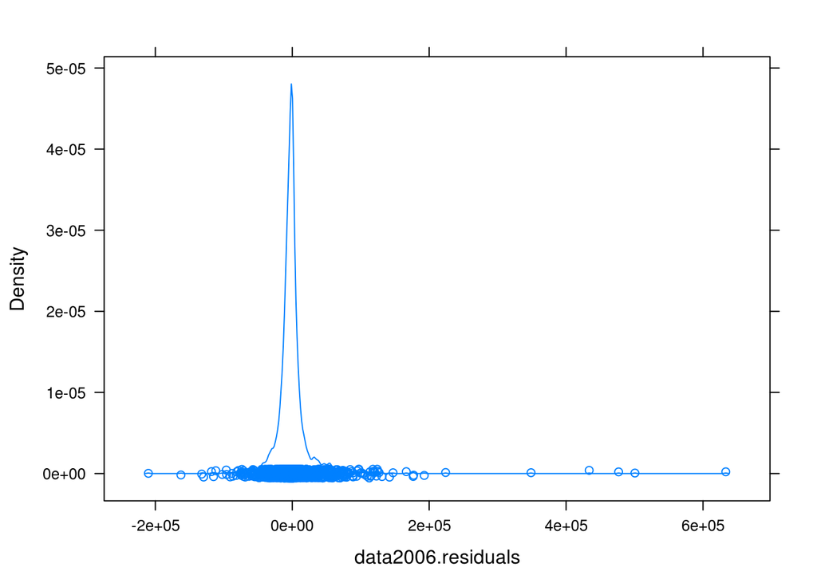

```r
data2006.residuals = resid(data2006.lm)

densityplot(data2006.residuals)
```

#### 2010

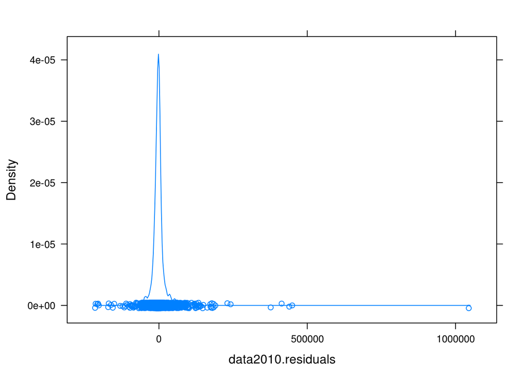

```r
data2010.residuals = resid(data2010.lm)

densityplot(data2010.residuals)
```

### 4. If there is redudant variables or not explained, make a new model excluding those variables and compare the new model with the one that has all variables (e.g. should explain using R2 and RSE)

> In order to reach a better model we’ve choose a few variables, numeric ones whit a good significance value, but the R-squared and adjusted got was smaller then the one whit all varialbes, also not a good regression model, not 2006 nor 2010. * 2006: R-squared: 0.4896, Adjusted R-squared: 0.4887 * 2010: R-squared: 0.4232, Adjusted R-squared: 0.4224

#### 2006

```r
data2006.lm2 = lm(data2006$votos ~ data2006$quantidade_doadores + data2006$total_receita + data2006$recursos_de_pessoas_fisicas + data2006$recursos_de_pessoas_juridicas + data2006$quantidade_despesas + data2006$total_despesa)

summary(data2006.lm2)
```

```
##
## Call:
## lm(formula = data2006$votos ~ data2006$quantidade_doadores +
##     data2006$total_receita + data2006$recursos_de_pessoas_fisicas +
##     data2006$recursos_de_pessoas_juridicas + data2006$quantidade_despesas +
##     data2006$total_despesa)
##
## Residuals:
##     Min      1Q  Median      3Q     Max
## -204719   -7949   -6859    -956  643363
##
## Coefficients:
##                                          Estimate Std. Error t value
## (Intercept)                             7.743e+03  6.353e+02  12.187
## data2006$quantidade_doadores            1.758e+02  1.650e+01  10.656
## data2006$total_receita                 -4.775e-02  1.247e-02  -3.828
## data2006$recursos_de_pessoas_fisicas    1.451e-01  1.511e-02   9.606
## data2006$recursos_de_pessoas_juridicas  4.441e-02  7.116e-03   6.241
## data2006$quantidade_despesas           -3.459e+01  3.178e+00 -10.882
## data2006$total_despesa                  1.457e-01  1.283e-02  11.353
##                                        Pr(>|t|)
## (Intercept)                             < 2e-16 ***
## data2006$quantidade_doadores            < 2e-16 ***
## data2006$total_receita                 0.000131 ***
## data2006$recursos_de_pessoas_fisicas    < 2e-16 ***
## data2006$recursos_de_pessoas_juridicas 4.89e-10 ***
## data2006$quantidade_despesas            < 2e-16 ***
## data2006$total_despesa                  < 2e-16 ***
## ---
## Signif. codes:  0 '***' 0.001 '**' 0.01 '*' 0.05 '.' 0.1 ' ' 1
##
## Residual standard error: 32520 on 3429 degrees of freedom
## Multiple R-squared:  0.4896, Adjusted R-squared:  0.4887
## F-statistic: 548.2 on 6 and 3429 DF,  p-value: < 2.2e-16
```

#### 2010

```r
data2010.lm2 = lm(data2010$votos ~ data2010$quantidade_doadores + data2010$total_receita + data2010$recursos_de_pessoas_fisicas + data2010$recursos_de_pessoas_juridicas + data2010$quantidade_despesas + data2010$total_despesa)

summary(data2010.lm2)
```

```
##
## Call:
## lm(formula = data2010$votos ~ data2010$quantidade_doadores +
##     data2010$total_receita + data2010$recursos_de_pessoas_fisicas +
##     data2010$recursos_de_pessoas_juridicas + data2010$quantidade_despesas +
##     data2010$total_despesa)
##
## Residuals:
##     Min      1Q  Median      3Q     Max
## -254392   -7977   -7252   -3340 1312919
##
## Coefficients:
##                                          Estimate Std. Error t value
## (Intercept)                             8.023e+03  6.493e+02  12.357
## data2010$quantidade_doadores            3.138e+01  5.586e+00   5.618
## data2010$total_receita                 -7.416e-03  8.266e-03  -0.897
## data2010$recursos_de_pessoas_fisicas    6.352e-02  9.156e-03   6.937
## data2010$recursos_de_pessoas_juridicas  1.621e-02  3.832e-03   4.230
## data2010$quantidade_despesas           -1.521e+01  2.132e+00  -7.134
## data2010$total_despesa                  6.872e-02  8.899e-03   7.723
##                                        Pr(>|t|)
## (Intercept)                             < 2e-16 ***
## data2010$quantidade_doadores           2.06e-08 ***
## data2010$total_receita                     0.37
## data2010$recursos_de_pessoas_fisicas   4.64e-12 ***
## data2010$recursos_de_pessoas_juridicas 2.39e-05 ***
## data2010$quantidade_despesas           1.15e-12 ***
## data2010$total_despesa                 1.43e-14 ***
## ---
## Signif. codes:  0 '***' 0.001 '**' 0.01 '*' 0.05 '.' 0.1 ' ' 1
##
## Residual standard error: 37660 on 4033 degrees of freedom
## Multiple R-squared:  0.4232, Adjusted R-squared:  0.4224
## F-statistic: 493.2 on 6 and 4033 DF,  p-value: < 2.2e-16
```

### 5. Make a regression including both years 2006 and 1010 together. Which differencies/similitaries are notices coparing whit the models whit individual year?

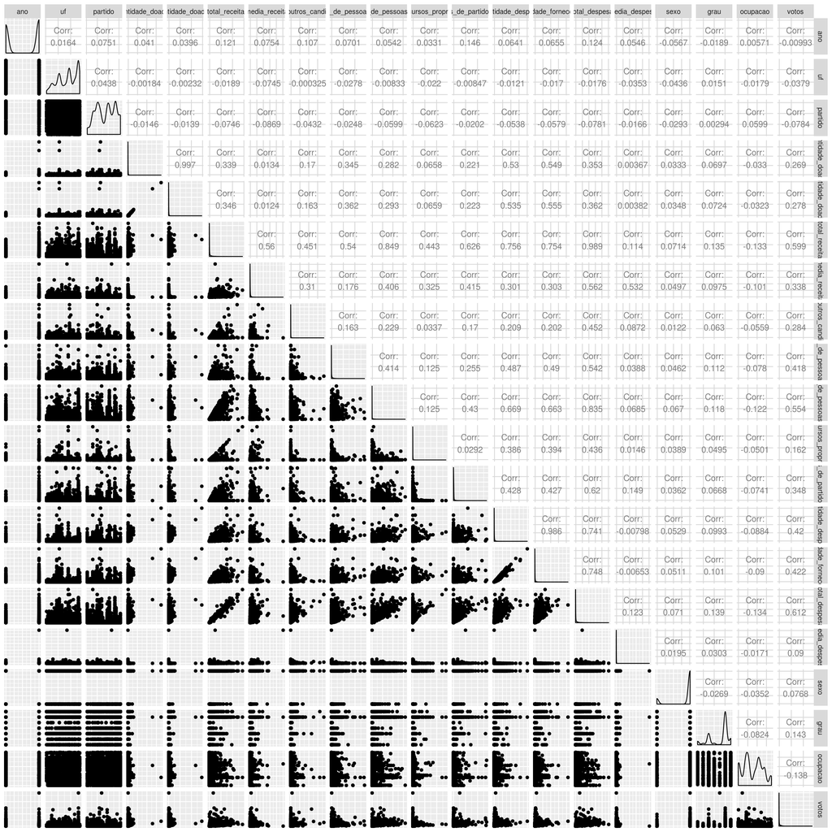

```r
data2006_2010.correlation1 <- data2006_2010 %>% select(-c(sequencial_candidato, nome, estado_civil, cargo))

data2006_2010.correlation <- data2006_2010.correlation1  %>%
  mutate(uf = as.numeric(uf)) %>%
  mutate(partido = as.numeric(partido)) %>%
  mutate(sexo = as.numeric(sexo)) %>%
  mutate(grau = as.numeric(grau)) %>%
  mutate(ocupacao = as.numeric(ocupacao))


ggpairs(data2006_2010.correlation, axisLabels = "none")
```

```r
data2006_2010.lm = lm(data2006_2010$votos ~ data2006_2010$uf + data2006_2010$partido  + data2006_2010$quantidade_doacoes + data2006_2010$quantidade_doadores + data2006_2010$total_receita + data2006_2010$media_receita + data2006_2010$recursos_de_outros_candidatos.comites + data2006_2010$recursos_de_pessoas_fisicas + data2006_2010$recursos_de_pessoas_juridicas + data2006_2010$recursos_proprios + data2006_2010$recursos_de_partido_politico + data2006_2010$quantidade_despesas + data2006_2010$quantidade_fornecedores + data2006_2010$total_despesa + data2006_2010$media_despesa + data2006_2010$sexo + data2006_2010$grau + data2006_2010$estado_civil + data2006_2010$ocupacao + data2006_2010$ano)

summary(data2006_2010.lm)
```

```
##
## Call:
## lm(formula = data2006_2010$votos ~ data2006_2010$uf + data2006_2010$partido +
##     data2006_2010$quantidade_doacoes + data2006_2010$quantidade_doadores +
##     data2006_2010$total_receita + data2006_2010$media_receita +
##     data2006_2010$recursos_de_outros_candidatos.comites + data2006_2010$recursos_de_pessoas_fisicas +
##     data2006_2010$recursos_de_pessoas_juridicas + data2006_2010$recursos_proprios +
##     data2006_2010$recursos_de_partido_politico + data2006_2010$quantidade_despesas +
##     data2006_2010$quantidade_fornecedores + data2006_2010$total_despesa +
##     data2006_2010$media_despesa + data2006_2010$sexo + data2006_2010$grau +
##     data2006_2010$estado_civil + data2006_2010$ocupacao + data2006_2010$ano)
##
## Residuals:
##     Min      1Q  Median      3Q     Max
## -265665  -10290   -2842    4093 1168971
##
## Coefficients: (1 not defined because of singularities)
##                                                                                                Estimate
## (Intercept)                                                                                   2.769e+06
## data2006_2010$ufAL                                                                            1.771e+04
## data2006_2010$ufAM                                                                            2.067e+04
## data2006_2010$ufAP                                                                            7.102e+03
## data2006_2010$ufBA                                                                            2.562e+04
## data2006_2010$ufCE                                                                            3.329e+04
## data2006_2010$ufDF                                                                            1.351e+04
## data2006_2010$ufES                                                                            1.559e+04
## data2006_2010$ufGO                                                                            1.219e+04
## data2006_2010$ufMA                                                                            2.197e+04
## data2006_2010$ufMG                                                                            1.664e+04
## data2006_2010$ufMS                                                                            1.233e+04
## data2006_2010$ufMT                                                                            1.195e+04
## data2006_2010$ufPA                                                                            2.729e+04
## data2006_2010$ufPB                                                                            2.415e+04
## data2006_2010$ufPE                                                                            2.413e+04
## data2006_2010$ufPI                                                                            2.165e+04
## data2006_2010$ufPR                                                                            1.856e+04
## data2006_2010$ufRJ                                                                            1.458e+04
## data2006_2010$ufRN                                                                            2.924e+04
## data2006_2010$ufRO                                                                            1.060e+04
## data2006_2010$ufRR                                                                           -2.623e+02
```

[output cut: 1253 more lines]

```
## data2006_2010$ocupacaoTRABALHADOR METALÚRGICO E SIDERÚRGICO
## data2006_2010$ocupacaoTRABALHADOR RURAL
## data2006_2010$ocupacaoVENDEDOR DE COMÉRCIO VAREJISTA E ATACADISTA
## data2006_2010$ocupacaoVENDEDOR PRACISTA, REPRESENTANTE, CAIXEIRO-VIAJANTE E ASSEMELHADOS
## data2006_2010$ocupacaoVEREADOR
## data2006_2010$ocupacaoVETERINÁRIO
## data2006_2010$ocupacaoVIGILANTE
## data2006_2010$ocupacaoZOOTECNISTA
## data2006_2010$ano                                                                            ***
## ---
## Signif. codes:  0 '***' 0.001 '**' 0.01 '*' 0.05 '.' 0.1 ' ' 1
##
## Residual standard error: 34050 on 7221 degrees of freedom
## Multiple R-squared:  0.5082, Adjusted R-squared:  0.4909
## F-statistic: 29.38 on 254 and 7221 DF,  p-value: < 2.2e-16
```

#### 2006 and 2010

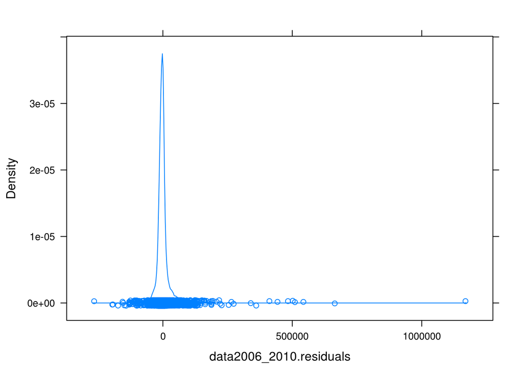

```r
data2006_2010.residuals = resid(data2006_2010.lm)

densityplot(data2006_2010.residuals)
```

```r
data2006_2010.lm = lm(data2006_2010$votos ~  data2006_2010$quantidade_doacoes + data2006_2010$total_receita + data2006_2010$recursos_de_outros_candidatos.comites + data2006_2010$recursos_de_pessoas_fisicas + data2006_2010$recursos_de_pessoas_juridicas + data2006_2010$recursos_proprios+ data2006_2010$quantidade_despesas + data2006_2010$total_despesa + data2006_2010$media_despesa +  data2006_2010$ano)

summary(data2006_2010.lm)
```

```
##
## Call:
## lm(formula = data2006_2010$votos ~ data2006_2010$quantidade_doacoes +
##     data2006_2010$total_receita + data2006_2010$recursos_de_outros_candidatos.comites +
##     data2006_2010$recursos_de_pessoas_fisicas + data2006_2010$recursos_de_pessoas_juridicas +
##     data2006_2010$recursos_proprios + data2006_2010$quantidade_despesas +
##     data2006_2010$total_despesa + data2006_2010$media_despesa +
##     data2006_2010$ano)
##
## Residuals:
##     Min      1Q  Median      3Q     Max
## -331666  -12312   -5675   -1689 1314758
##
## Coefficients:
##                                                       Estimate Std. Error
## (Intercept)                                          4.110e+06  4.324e+05
## data2006_2010$quantidade_doacoes                     3.122e+01  4.467e+00
## data2006_2010$total_receita                         -3.177e-02  7.434e-03
## data2006_2010$recursos_de_outros_candidatos.comites  1.743e-02  5.730e-03
## data2006_2010$recursos_de_pessoas_fisicas            9.655e-02  8.295e-03
## data2006_2010$recursos_de_pessoas_juridicas          3.699e-02  4.761e-03
## data2006_2010$recursos_proprios                     -7.425e-03  4.575e-03
## data2006_2010$quantidade_despesas                   -1.638e+01  1.860e+00
## data2006_2010$total_despesa                          9.125e-02  7.364e-03
## data2006_2010$media_despesa                          1.022e-01  6.952e-02
## data2006_2010$ano                                   -2.042e+03  2.153e+02
##                                                     t value Pr(>|t|)
## (Intercept)                                           9.506  < 2e-16 ***
## data2006_2010$quantidade_doacoes                      6.990 2.99e-12 ***
## data2006_2010$total_receita                          -4.274 1.95e-05 ***
## data2006_2010$recursos_de_outros_candidatos.comites   3.042  0.00236 **
## data2006_2010$recursos_de_pessoas_fisicas            11.640  < 2e-16 ***
## data2006_2010$recursos_de_pessoas_juridicas           7.768 9.02e-15 ***
## data2006_2010$recursos_proprios                      -1.623  0.10462
## data2006_2010$quantidade_despesas                    -8.806  < 2e-16 ***
## data2006_2010$total_despesa                          12.392  < 2e-16 ***
## data2006_2010$media_despesa                           1.470  0.14171
## data2006_2010$ano                                    -9.484  < 2e-16 ***
## ---
## Signif. codes:  0 '***' 0.001 '**' 0.01 '*' 0.05 '.' 0.1 ' ' 1
##
## Residual standard error: 36510 on 7465 degrees of freedom
## Multiple R-squared:  0.4156, Adjusted R-squared:  0.4148
## F-statistic: 530.9 on 10 and 7465 DF,  p-value: < 2.2e-16
```